# Chapter 13

Scott Spencer

9/1/2018

The code below is meant as a directly-in-Stan translation of the examples in Chapter 13 of McElreath’s *Statistical Rethinking*.

## 13.1 Varying slopes by construction

### 13.1.1 simulate the population

Simulate data

```r
a <- 3.5
b <- (-1)
sigma_a <- 1
sigma_b <- 0.5
rho <- (-0.7)
Mu <- c(a, b)
cov_ab <- sigma_a * sigma_b * rho
```

Setup the covariance matrix

```r
# approach 1
Sigma <- matrix( c(sigma_a^2, cov_ab, cov_ab, sigma_b^2), ncol = 2 )

# approach 2
sigmas <- c(sigma_a, sigma_b)
Rho <- matrix(c(1, rho, rho, 1), nrow = 2)
Sigma <- diag(sigmas) %*% Rho %*% diag(sigmas)
```

simulate cafes

```r
N_cafes <- 20
library(MASS)
set.seed(5)
vary_effects <- mvrnorm(N_cafes, Mu, Sigma)
```

separate the intercepts and slopes

```r
a_cafe <- vary_effects[,1]
b_cafe <- vary_effects[,2]
```

Figure 13.2

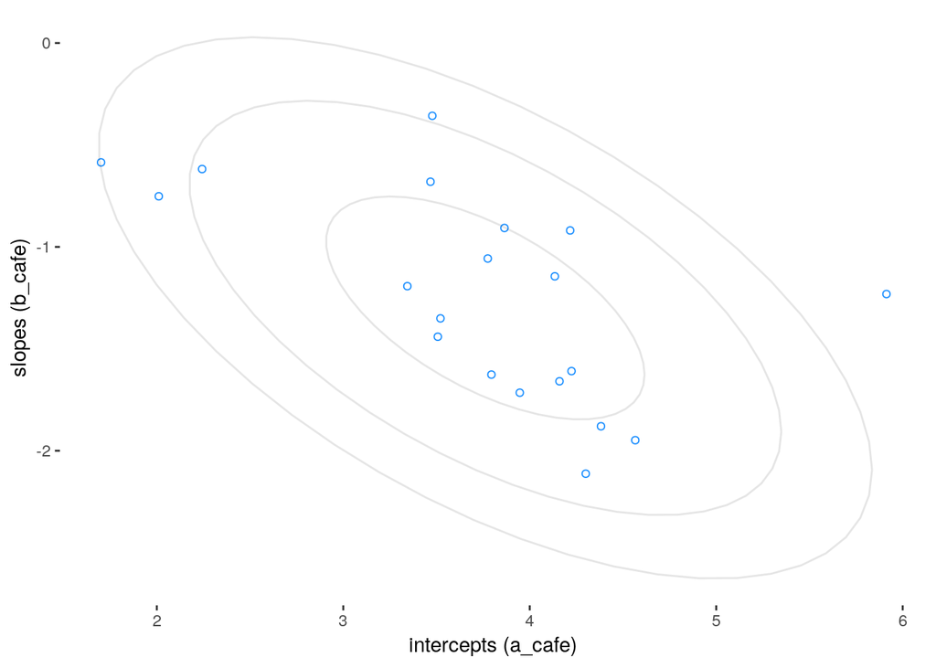

```r
ggplot() +
  geom_point(aes(a_cafe, b_cafe), shape = 21, color = 'dodgerblue') +
  stat_ellipse(aes(a_cafe, b_cafe), level = .50, alpha = .1) +
  stat_ellipse(aes(a_cafe, b_cafe), level = .89, alpha = .1) +
  stat_ellipse(aes(a_cafe, b_cafe), level = .97, alpha = .1) +
  labs(x = 'intercepts (a_cafe)', y = 'slopes (b_cafe)')
```

### 13.1.2 simulate observations

```r
N_visits <- 10
afternoon <- rep(0:1, N_visits * N_cafes / 2)
cafe_id <- rep(1:N_cafes, each = N_visits)
mu <- a_cafe[cafe_id] + b_cafe[cafe_id] * afternoon
sigma <- 0.5
wait <- rnorm(N_visits * N_cafes, mu, sigma)
d <- data.frame(cafe = cafe_id, afternoon = afternoon, wait = wait)
```

### 13.1.3 the varying slopes model

Code a model in Stan.

```stan
data {
  int N;
  int N_cafe;
  int cafe_id[N];
  real W[N];
  int A[N];
}
parameters {
  real a;
  real b;
  vector[N_cafe] a_cafe;
  vector[N_cafe] b_cafe;
  real<lower=0> sigma;
  vector<lower=0>[2] sigma_cafe;
  corr_matrix[2] Rho;
}
transformed parameters {
  vector[2] Mu_ab = [a, b]';
  vector[2] v_a_cafeb_cafe[N_cafe];
  cov_matrix[2] SRS_sigma_cafeRho;
  for ( j in 1:N_cafe ) v_a_cafeb_cafe[j,1:2] = [a_cafe[j], b_cafe[j]]';
  SRS_sigma_cafeRho = quad_form_diag(Rho,sigma_cafe);
}
model {
  vector[N] mu;

  //priors
  target += normal_lpdf(a | 0, 10);
  target += normal_lpdf(b | 0, 10);
  target += cauchy_lpdf(sigma | 0 , 2 );
  target += cauchy_lpdf(sigma_cafe | 0 , 2 );
  target += lkj_corr_lpdf(Rho | 2 );

  // linear model
  for(i in 1:N) mu[i] = a_cafe[cafe_id[i]] + b_cafe[cafe_id[i]] * A[i];

  target += normal_lpdf(W | mu, sigma);
  target += multi_normal_lpdf(v_a_cafeb_cafe | Mu_ab , SRS_sigma_cafeRho );
}
generated quantities {
  vector[N] log_lik;
  {
  vector[N] mu;
  for(i in 1:N) {
    mu[i] = a_cafe[cafe_id[i]] + b_cafe[cafe_id[i]] * A[i];
    log_lik[i] = normal_lpdf(W[i] | mu[i], sigma);
  }
  }
}
```

Organize data and sample from model.

```r
dat <- list(
  N = NROW(d),
  N_cafe = max(d$cafe),
  cafe_id = d$cafe,
  W = d$wait,
  A = d$afternoon
)

fit13_1 <- sampling(m13_1, data = dat, iter = 5000, chains = 2, cores = 2)
```

```r
print(fit13_1, include = F, pars = 'log_lik', probs = c(.1, .5, .9))
```

```
## Inference for Stan model: bc7b53704c78f319ad79c0220bef0159.
## 2 chains, each with iter=5000; warmup=2500; thin=1;
## post-warmup draws per chain=2500, total post-warmup draws=5000.
##
##                           mean se_mean    sd     10%     50%     90% n_eff
## a                         3.74    0.00  0.21    3.47    3.75    4.00  3770
## b                        -1.24    0.00  0.09   -1.35   -1.24   -1.13  2319
## a_cafe[1]                 4.09    0.00  0.17    3.88    4.09    4.31  3456
## a_cafe[2]                 2.37    0.00  0.18    2.14    2.37    2.61  2058
## a_cafe[3]                 3.95    0.00  0.18    3.72    3.95    4.18  1486
## a_cafe[4]                 3.46    0.00  0.18    3.24    3.47    3.68  2693
## a_cafe[5]                 2.14    0.00  0.18    1.90    2.14    2.37  2172
## a_cafe[6]                 4.27    0.00  0.17    4.05    4.27    4.51  1690
## a_cafe[7]                 3.57    0.00  0.18    3.34    3.57    3.78  2509
## a_cafe[8]                 3.80    0.00  0.18    3.58    3.81    4.03  2807
## a_cafe[9]                 3.89    0.00  0.18    3.67    3.89    4.12  2815
## a_cafe[10]                3.69    0.00  0.18    3.47    3.69    3.93  1277
## a_cafe[11]                2.47    0.01  0.20    2.21    2.47    2.73   597
## a_cafe[12]                4.08    0.00  0.17    3.87    4.09    4.31  2594
## a_cafe[13]                3.89    0.00  0.18    3.67    3.89    4.13  3316
## a_cafe[14]                3.34    0.00  0.18    3.11    3.35    3.58  1657
## a_cafe[15]                4.25    0.01  0.20    4.01    4.25    4.51  1236
## a_cafe[16]                3.59    0.00  0.18    3.36    3.59    3.83  1392
## a_cafe[17]                4.44    0.01  0.19    4.20    4.43    4.68   971
## a_cafe[18]                6.10    0.00  0.19    5.86    6.11    6.35  2118
## a_cafe[19]                3.49    0.00  0.19    3.25    3.50    3.72  1920
## a_cafe[20]                3.90    0.01  0.19    3.66    3.91    4.14  1249
## b_cafe[1]                -1.30    0.00  0.18   -1.54   -1.29   -1.09  3069
## b_cafe[2]                -1.20    0.00  0.19   -1.43   -1.20   -0.96  3860
## b_cafe[3]                -1.27    0.00  0.18   -1.49   -1.27   -1.05  4199
## b_cafe[4]                -1.30    0.00  0.18   -1.53   -1.29   -1.08  3716
## b_cafe[5]                -1.26    0.00  0.20   -1.51   -1.25   -1.01  3283
## b_cafe[6]                -1.29    0.00  0.18   -1.53   -1.28   -1.07  4111
## b_cafe[7]                -1.23    0.00  0.17   -1.45   -1.24   -1.01  4394
## b_cafe[8]                -1.26    0.00  0.18   -1.49   -1.26   -1.04  3685
## b_cafe[9]                -1.14    0.00  0.19   -1.36   -1.16   -0.88  1597
## b_cafe[10]               -1.20    0.00  0.18   -1.41   -1.21   -0.97  3532
## b_cafe[11]               -1.03    0.01  0.23   -1.29   -1.05   -0.72   745
## b_cafe[12]               -1.22    0.00  0.18   -1.43   -1.22   -0.99  3347
## b_cafe[13]               -1.33    0.00  0.19   -1.59   -1.32   -1.11  2166
```

[output cut: 148 more lines]

```
## v_a_cafeb_cafe[18,2]   1.00
## v_a_cafeb_cafe[19,1]   1.00
## v_a_cafeb_cafe[19,2]   1.00
## v_a_cafeb_cafe[20,1]   1.00
## v_a_cafeb_cafe[20,2]   1.00
## SRS_sigma_cafeRho[1,1] 1.00
## SRS_sigma_cafeRho[1,2] 1.00
## SRS_sigma_cafeRho[2,1] 1.00
## SRS_sigma_cafeRho[2,2] 1.00
## lp__                   1.02
##
## Samples were drawn using NUTS(diag_e) at Thu Jan 17 12:14:29 2019.
## For each parameter, n_eff is a crude measure of effective sample size,
## and Rhat is the potential scale reduction factor on split chains (at
## convergence, Rhat=1).
```

Examine correlation.

Figure 13.4

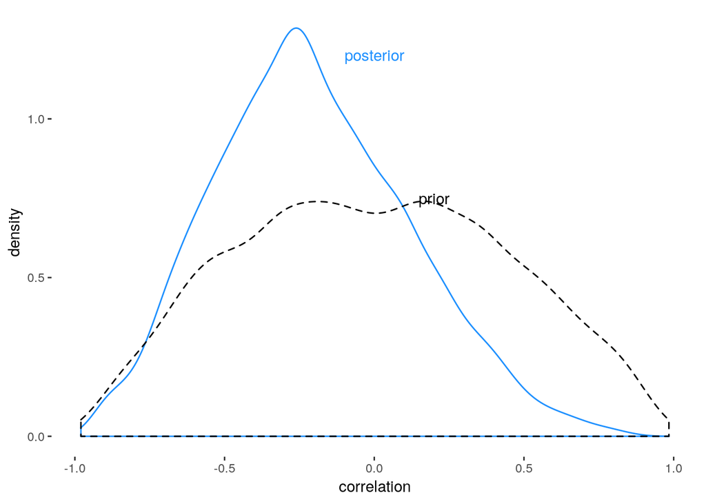

```r
rho_prior <- rethinking::rlkjcorr(5000, 2, 2)

post13_1 <- as.data.frame(fit13_1)

ggplot(post13_1) +
  geom_density(aes(x = `Rho[1,2]`), color = 'dodgerblue') +
  geom_density(aes(x = rho_prior[, 1, 2]), linetype = 'dashed') +
  annotate('text', x=0.2, y = .75, label = 'prior') +
  annotate('text', x=0, y = 1.2, label = 'posterior', color = 'dodgerblue') +
  labs(x = 'correlation')
```

Compare slope and intercept for regularized varying effects to unpooled estimates.

Figure 13.5 left side

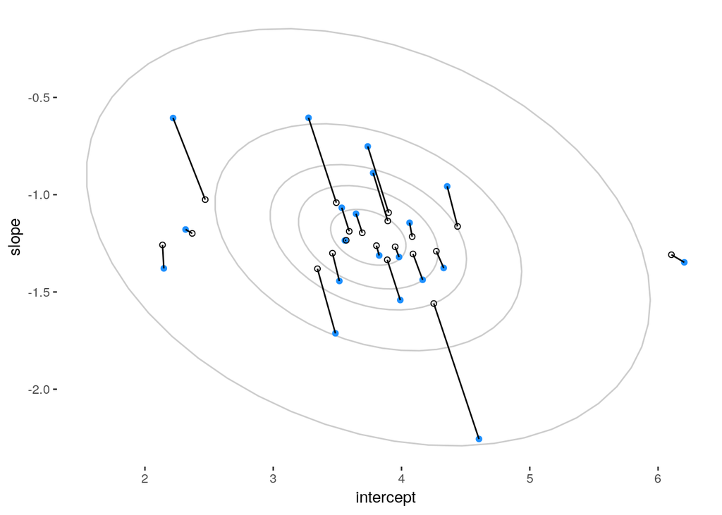

```r
# calculate unpooled estimates from the data
a1 <- sapply(1:N_cafes, function(i) mean(wait[cafe_id == i & afternoon == 0]))
b1 <- sapply(1:N_cafes, function(i) mean(wait[cafe_id == i & afternoon == 1])) - a1

# extract posterior means from partially pooled estimates
a2 <- apply(post13_1[,grep('^a_cafe', colnames(post13_1))], 2, mean)
b2 <- apply(post13_1[,grep('^b_cafe', colnames(post13_1))], 2, mean)

df <- data.frame(a1, b1, a2, b2)

# plot both
ggplot(df) + theme_tufte(base_family = 'sans') +
  stat_ellipse(aes(x = a1, y = b1), level = .1, alpha = .2) +
  stat_ellipse(aes(x = a1, y = b1), level = .3, alpha = .2) +
  stat_ellipse(aes(x = a1, y = b1), level = .5, alpha = .2) +
  stat_ellipse(aes(x = a1, y = b1), level = .8, alpha = .2) +
  stat_ellipse(aes(x = a1, y = b1), level = .99, alpha = .2) +
  geom_point(aes(x = a1, y = b1), color = 'dodgerblue') +
  geom_point(aes(x = a2, y = b2), shape = 21) +
  geom_segment(aes(x = a1, xend = a2, y = b1, yend = b2)) +
  labs(x = 'intercept', y = 'slope')
```

Compare wait times for regularized varying effects to unpooled estimates.

Figure 13.5 Right side

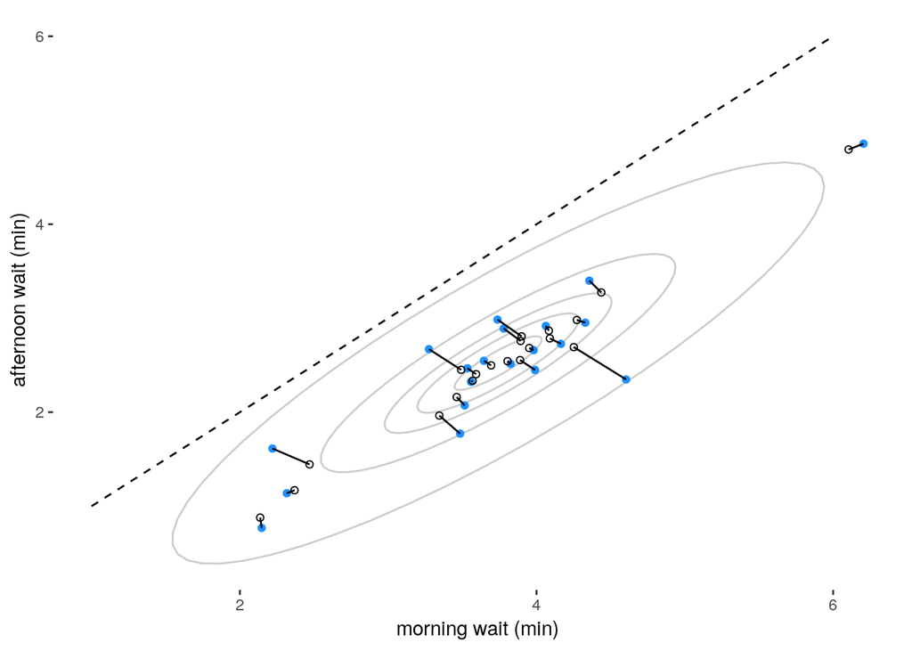

```r
df <- df %>%
  mutate(w_morning1 = a1,
         w_afternoon1 = a1 + b1,
         w_morning2 = a2,
         w_afternoon2 = a2 + b2)

ggplot(df) + theme_tufte(base_family = 'sans') +
  stat_ellipse(aes(x = w_morning1, y = w_afternoon1), level = .1, alpha = .2) +
  stat_ellipse(aes(x = w_morning1, y = w_afternoon1), level = .3, alpha = .2) +
  stat_ellipse(aes(x = w_morning1, y = w_afternoon1), level = .5, alpha = .2) +
  stat_ellipse(aes(x = w_morning1, y = w_afternoon1), level = .8, alpha = .2) +
  stat_ellipse(aes(x = w_morning1, y = w_afternoon1), level = .99, alpha = .2) +
  geom_point(aes(x = w_morning1, y = w_afternoon1), color = 'dodgerblue') +
  geom_point(aes(x = a2, y = w_afternoon2), shape = 21) +
  geom_segment(aes(x = w_morning1, xend = w_morning2, y = w_afternoon1, yend = w_afternoon2)) +
  geom_line(data = data.frame(x = seq(6)), aes(x = x, y = x), linetype = 'dashed') +
  labs(x = 'morning wait (min)', y = 'afternoon wait (min)')
```

## 13.2 example: admissions decision and gender

Load data.

```r
data('UCBadmit', package = 'rethinking')
d <- UCBadmit; rm(UCBadmit)
d <- d %>% mutate(male = applicant.gender == 'male',
                  dept_id = as.integer(dept))
```

### 13.2.1. Varying intercepts

Code model in Stan.

```stan
data {
  int N;
  int n[N];
  int m[N];
  int A[N];
  int N_depts;
  int dept[N];
}
parameters {
  real alpha;
  real beta;
  real<lower=0> sigma;
  vector[N_depts] a_dept;
}
model {
  vector[N] p;
  target += normal_lpdf(a_dept | alpha, sigma);
  target += normal_lpdf(alpha | 0, 10);
  target += normal_lpdf(beta | 0, 1);
  target += cauchy_lpdf(sigma | 0, 2);
  for(i in 1:N) p[i] = a_dept[dept[i]] + beta * m[i];
  target += binomial_logit_lpmf(A | n, p);
}
generated quantities {
  vector[N] log_lik;
  {
  vector[N] p;
  for (i in 1:N) {
    p[i] = a_dept[dept[i]] + beta * m[i];
    log_lik[i] = binomial_logit_lpmf(A[i] | n[i], p[i]);
  }
  }
}
```

Organize data and sample from model.

```r
dat <- list(
  N = NROW(d),
  n = d$applications,
  m = d$male,
  A = d$admit,
  N_depts = max(d$dept_id),
  dept = d$dept_id
)

fit13_2 <- sampling(m13_2, data = dat, iter = 1000, chains = 2, cores = 2)
```

Summarize the model

```r
print(fit13_2, include = F, pars = 'log_lik', probs = c(.1, .5, .9))
```

```
## Inference for Stan model: 0a0b612873318506b73964589262417c.
## 2 chains, each with iter=1000; warmup=500; thin=1;
## post-warmup draws per chain=500, total post-warmup draws=1000.
##
##             mean se_mean   sd    10%    50%    90% n_eff Rhat
## alpha      -0.55    0.03 0.73  -1.35  -0.54   0.27   576 1.00
## beta       -0.10    0.00 0.08  -0.20  -0.10   0.00   481 1.01
## sigma       1.52    0.02 0.63   0.93   1.36   2.27   663 1.00
## a_dept[1]   0.68    0.00 0.10   0.55   0.68   0.80   569 1.01
## a_dept[2]   0.63    0.00 0.11   0.49   0.63   0.77   570 1.01
## a_dept[3]  -0.58    0.00 0.07  -0.67  -0.58  -0.49   681 1.00
## a_dept[4]  -0.62    0.00 0.08  -0.72  -0.62  -0.51   768 1.00
## a_dept[5]  -1.06    0.00 0.10  -1.18  -1.05  -0.94  1279 1.00
## a_dept[6]  -2.60    0.01 0.16  -2.81  -2.60  -2.41  1013 1.00
## lp__      -64.57    0.13 2.37 -67.67 -64.14 -61.98   347 1.01
##
## Samples were drawn using NUTS(diag_e) at Thu Jan 17 12:15:16 2019.
## For each parameter, n_eff is a crude measure of effective sample size,
## and Rhat is the potential scale reduction factor on split chains (at
## convergence, Rhat=1).
```

### 13.2.2 varying effects of being male

Code model in Stan.

```stan
data {
  int N;
  int n[N];
  real m[N];
  int A[N];
  int N_depts;
  int dept[N];
}
parameters {
  real a;
  real b;
  vector[N_depts] a_dept;
  vector[N_depts] b_dept;
  vector<lower=0>[2] sigma_dept;
  corr_matrix[2] rho;
}
transformed parameters {
  vector[2] mu_ab;
  cov_matrix[2] Sigma;
  vector[2] v_a_deptb_dept[N_depts];

  for(j in 1:N_depts) v_a_deptb_dept[j, 1:2] = [a_dept[j], b_dept[j]]';

  mu_ab = [a, b]';
  Sigma = quad_form_diag(rho, sigma_dept);
}
model {
  vector[N] p;

  // priors
  target += normal_lpdf(a | 0, 10);
  target += normal_lpdf(b | 0, 1);
  target += cauchy_lpdf(sigma_dept | 0, 2);
  target += lkj_corr_lpdf(rho | 2);

  for (i in 1:N) p[i] = a_dept[dept[i]] + b_dept[dept[i]] * m[i];

  target += binomial_logit_lpmf(A | n, p);
  target += multi_normal_lpdf(v_a_deptb_dept | mu_ab, Sigma);
}
generated quantities {
  vector[N] log_lik;
  {
  vector[N] p;
  for(i in 1:N) {
    p[i] = a_dept[dept[i]] + b_dept[dept[i]] * m[i];
    log_lik[i] = binomial_logit_lpmf(A[i] | n[i], p[i]);
  }
  }
}
```

Sample from model.

```r
fit13_3 <- sampling(m13_3, data = dat, iter = 1000, chains = 2, cores = 2)
```

```r
print(fit13_3, include = F, pars = 'log_lik', probs = c(.1, .5, .9))
```

```
## Inference for Stan model: 52af0f44c470324a1be4fe6f273d9719.
## 2 chains, each with iter=1000; warmup=500; thin=1;
## post-warmup draws per chain=500, total post-warmup draws=1000.
##
##                       mean se_mean   sd    10%    50%    90% n_eff Rhat
## a                    -0.48    0.03 0.72  -1.36  -0.47   0.41   747 1.00
## b                    -0.17    0.01 0.25  -0.44  -0.16   0.12   588 1.00
## a_dept[1]             1.30    0.01 0.26   0.97   1.29   1.62   553 1.00
## a_dept[2]             0.73    0.01 0.30   0.36   0.73   1.11   705 1.00
## a_dept[3]            -0.65    0.00 0.09  -0.77  -0.65  -0.53   613 1.00
## a_dept[4]            -0.62    0.00 0.11  -0.76  -0.62  -0.49   825 1.00
## a_dept[5]            -1.13    0.00 0.11  -1.28  -1.13  -0.99  1017 1.00
## a_dept[6]            -2.60    0.01 0.20  -2.86  -2.60  -2.34  1001 1.00
## b_dept[1]            -0.78    0.01 0.27  -1.13  -0.78  -0.42   538 1.00
## b_dept[2]            -0.20    0.01 0.29  -0.58  -0.20   0.16   695 1.00
## b_dept[3]             0.08    0.01 0.15  -0.11   0.09   0.27   566 1.00
## b_dept[4]            -0.09    0.00 0.14  -0.27  -0.09   0.10   880 1.00
## b_dept[5]             0.13    0.01 0.19  -0.10   0.13   0.37   827 1.00
## b_dept[6]            -0.12    0.01 0.27  -0.47  -0.12   0.22   698 1.00
## sigma_dept[1]         1.64    0.02 0.58   1.06   1.52   2.35   567 1.00
## sigma_dept[2]         0.49    0.02 0.28   0.24   0.44   0.78   293 1.02
## rho[1,1]              1.00     NaN 0.00   1.00   1.00   1.00   NaN  NaN
## rho[1,2]             -0.32    0.01 0.35  -0.74  -0.36   0.15   665 1.00
## rho[2,1]             -0.32    0.01 0.35  -0.74  -0.36   0.15   665 1.00
## rho[2,2]              1.00    0.00 0.00   1.00   1.00   1.00   981 1.00
## mu_ab[1]             -0.48    0.03 0.72  -1.36  -0.47   0.41   747 1.00
## mu_ab[2]             -0.17    0.01 0.25  -0.44  -0.16   0.12   588 1.00
## Sigma[1,1]            3.02    0.12 2.64   1.12   2.32   5.52   526 1.00
## Sigma[1,2]           -0.26    0.03 0.63  -0.71  -0.20   0.10   608 1.00
## Sigma[2,1]           -0.26    0.03 0.63  -0.71  -0.20   0.10   608 1.00
## Sigma[2,2]            0.32    0.03 0.56   0.06   0.19   0.61   465 1.01
## v_a_deptb_dept[1,1]   1.30    0.01 0.26   0.97   1.29   1.62   553 1.00
## v_a_deptb_dept[1,2]  -0.78    0.01 0.27  -1.13  -0.78  -0.42   538 1.00
## v_a_deptb_dept[2,1]   0.73    0.01 0.30   0.36   0.73   1.11   705 1.00
## v_a_deptb_dept[2,2]  -0.20    0.01 0.29  -0.58  -0.20   0.16   695 1.00
## v_a_deptb_dept[3,1]  -0.65    0.00 0.09  -0.77  -0.65  -0.53   613 1.00
## v_a_deptb_dept[3,2]   0.08    0.01 0.15  -0.11   0.09   0.27   566 1.00
## v_a_deptb_dept[4,1]  -0.62    0.00 0.11  -0.76  -0.62  -0.49   825 1.00
## v_a_deptb_dept[4,2]  -0.09    0.00 0.14  -0.27  -0.09   0.10   880 1.00
## v_a_deptb_dept[5,1]  -1.13    0.00 0.11  -1.28  -1.13  -0.99  1017 1.00
## v_a_deptb_dept[5,2]   0.13    0.01 0.19  -0.10   0.13   0.37   827 1.00
## v_a_deptb_dept[6,1]  -2.60    0.01 0.20  -2.86  -2.60  -2.34  1001 1.00
## v_a_deptb_dept[6,2]  -0.12    0.01 0.27  -0.47  -0.12   0.22   698 1.00
## lp__                -63.92    0.19 3.30 -68.26 -63.53 -60.05   300 1.02
##
## Samples were drawn using NUTS(diag_e) at Thu Jan 17 12:16:13 2019.
## For each parameter, n_eff is a crude measure of effective sample size,
## and Rhat is the potential scale reduction factor on split chains (at
## convergence, Rhat=1).
```

13.2.3. Shrinkage

Figure 13.6 left side

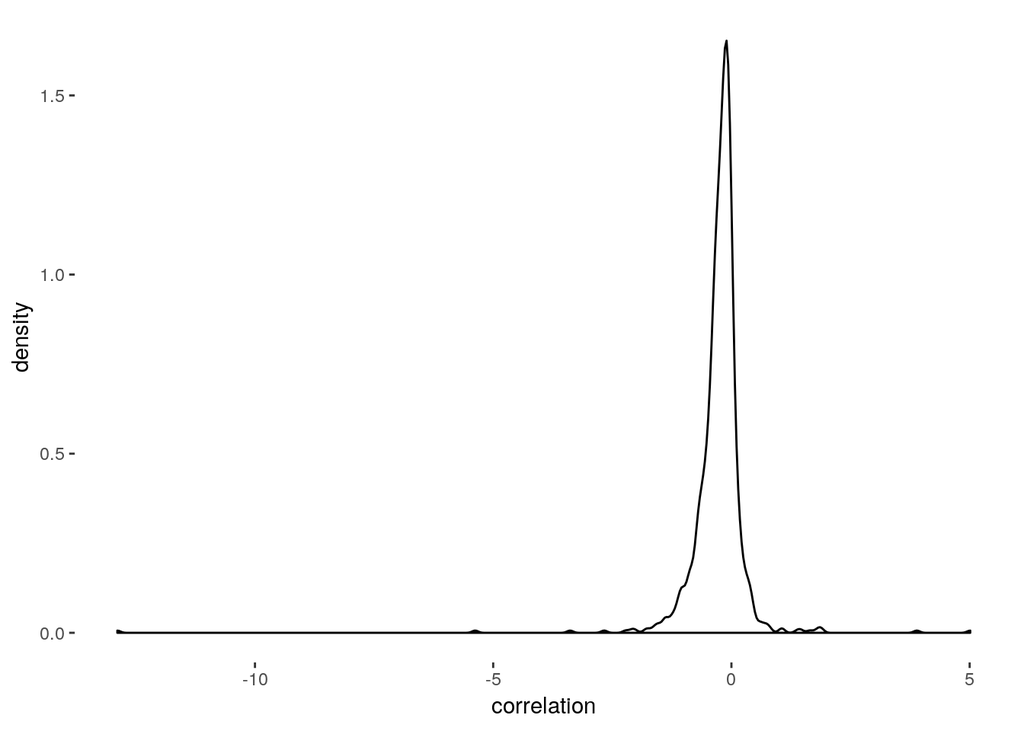

```r
post13_3 <- as.data.frame(fit13_3)
ggplot() +
  geom_density(aes(post13_3$`Sigma[1,2]`)) +
  labs(x = 'correlation')
```

Figure 13.6 Right side

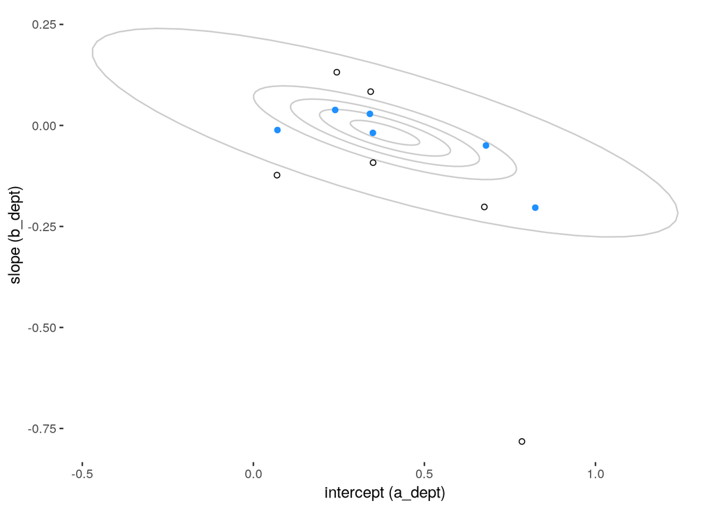

```r
a1 <- d %>% filter(male == 0) %>% group_by(dept_id) %>% summarise(avg = admit/applications) %>% .$avg
b1 <- d %>% filter(male == 1) %>% group_by(dept_id) %>% summarise(avg = admit/applications) %>% .$avg - a1

a2 <- apply(post13_3[, grep('^a_dept', colnames(post13_3))], 2, mean)
b2 <- apply(post13_3[, grep('^b_dept', colnames(post13_3))], 2, mean)
a2 <- a2 %>% plogis
df <- data.frame(a1, b1, a2, b2)

ggplot(df) + theme_tufte(base_family = 'sans') +
  stat_ellipse(aes(x = a1, y = b1), level = .1, alpha = .2) +
  stat_ellipse(aes(x = a1, y = b1), level = .3, alpha = .2) +
  stat_ellipse(aes(x = a1, y = b1), level = .5, alpha = .2) +
  stat_ellipse(aes(x = a1, y = b1), level = .7, alpha = .2) +
  stat_ellipse(aes(x = a1, y = b1), level = .97, alpha = .2) +
  geom_point(aes(a1, b1), color = 'dodgerblue') +
  geom_point(aes(a2, b2), shape = 21) +
  labs(x = 'intercept (a_dept)', y = 'slope (b_dept)')
```

### 13.2.4 Model comparisons

Code model without gender.

```stan
data {
  int N;
  int N_depts;
  int A[N];
  int n[N];
  int dept[N];
}
parameters {
  vector[N_depts] a_dept;
  real a;
  real<lower=0> sigma_dept;
}
model {
  vector[N] p;
  target += normal_lpdf(a_dept[dept] | a, sigma_dept);
  target += normal_lpdf(a | 0, 10);
  target += cauchy_lpdf(sigma_dept | 0, 2);
  p = a_dept[dept];
  target += binomial_logit_lpmf(A | n, p);
}
generated quantities {
  vector[N] log_lik;
  {
  vector[N] p;
  for(i in 1:N) {
    p = a_dept[dept];
    log_lik[i] = binomial_logit_lpmf(A[i] | n[i], p[i]);
  }
  }
}
```

Sample from model.

```r
fit13_4 <- sampling(m13_4, data = dat, iter = 1000, chains = 2, cores = 2)
```

Compare models.

```r
# extract log likelihoods
library(loo)
ll13_2 <- extract_log_lik(fit13_2)
ll13_3 <- extract_log_lik(fit13_3)
ll13_4 <- extract_log_lik(fit13_4)

# calculate reff
neff13_2 <- relative_eff(ll13_2, chain_id = c(rep(1, 500), rep(2, 500)), cores =2)
neff13_3 <- relative_eff(ll13_3, chain_id = c(rep(1, 500), rep(2, 500)), cores =2)
neff13_4 <- relative_eff(ll13_4, chain_id = c(rep(1, 500), rep(2, 500)), cores =2)

# calculate waics
waic13_2 <- waic(ll13_2, r_eff = reff13_2, cores = 2)
waic13_3 <- waic(ll13_3, r_eff = reff13_3, cores = 2)
waic13_4 <- waic(ll13_4, r_eff = reff13_4, cores = 2)

# compare
compare(waic13_2, waic13_3, waic13_4)
```

```
##          elpd_diff elpd_waic se_elpd_waic p_waic se_p_waic waic  se_waic
## waic13_3   0.0     -45.8       2.6          7.0    1.4      91.6   5.1
## waic13_4  -6.7     -52.5       9.0          6.2    2.0     104.9  18.0
## waic13_2  -8.0     -53.8       8.1          9.0    2.9     107.6  16.2
```

## 13.3 Example: cross-classified chimpanzees with varying slopes

load the data.

```r
data('chimpanzees', package = 'rethinking')
d <- chimpanzees; rm(chimpanzees)
```

Code the model in Stan.

```stan
data {
  int N;
  int N_actors;
  int N_blocks;
  int L[N]; // pulled left
  int C[N]; // condition
  int P[N]; // prosocial left
  int actor_id[N];
  int block_id[N];
}
parameters {
  real a;
  real bp;
  real bpc;
  vector[N_actors] a_actor;
  vector[N_actors] bp_actor;
  vector[N_actors] bpc_actor;

  vector[N_blocks] a_block;
  vector[N_blocks] bp_block;
  vector[N_blocks] bpc_block;

  vector<lower=0>[3] sigma_block;
  vector<lower=0>[3] sigma_actor;
  corr_matrix[3] Rho_actor;
  corr_matrix[3] Rho_block;
}
transformed parameters {
  vector[3] v_block[N_blocks];
  cov_matrix[3] SRS_block;
  vector[3] v_actor[N_actors];
  cov_matrix[3] SRS_actor;

  for(j in 1:N_blocks) v_block[j] = [a_block[j], bp_block[j], bpc_block[j]]';
  SRS_block = quad_form_diag(Rho_block, sigma_block);

  for(j in 1:N_actors) v_actor[j] = [a_actor[j], bp_actor[j], bpc_actor[j]]';
  SRS_actor = quad_form_diag(Rho_actor, sigma_actor);
}
model {
  vector[N] p;
  vector[N] A;
  vector[N] Bp;
  vector[N] Bpc;

  target += multi_normal_lpdf(v_block | rep_vector(0, 3), SRS_block);
  target += multi_normal_lpdf(v_actor | rep_vector(0, 3), SRS_actor);

  // linear models
  A = a + a_actor[actor_id] + a_block[block_id];
  Bp = bp + bp_actor[actor_id] + bp_block[block_id];
  Bpc = bpc + bpc_actor[actor_id] + bpc_block[block_id];
  for (i in 1:N) p[i] = A[i] + (Bp[i] + Bpc[i] * C[i]) * P[i];

  // likelihood
  target += binomial_logit_lpmf(L | 1, p);
}
generated quantities {
  vector[N] log_lik;
  {
  vector[N] p;
  vector[N] A;
  vector[N] Bp;
  vector[N] Bpc;

  A = a + a_actor[actor_id] + a_block[block_id];
  Bp = bp + bp_actor[actor_id] + bp_block[block_id];
  Bpc = bpc + bpc_actor[actor_id] + bpc_block[block_id];
  for (i in 1:N) {
    p[i] = A[i] + (Bp[i] + Bpc[i] * C[i]) * P[i];
    log_lik[i] = binomial_logit_lpmf(L[i] | 1, p[i]);
  }
  }
}
```

Organize data and sample from model.

```r
dat <- list(
  N = NROW(d),
  N_actors = max(d$actor),
  N_blocks = max(d$block),
  L = d$pulled_left,
  C = d$condition,
  P = d$prosoc_left,
  actor_id = d$actor,
  block_id = d$block
)

fit13_6 <- sampling(m13_6, data = dat, iter = 1000, chains = 2, cores = 2)
```

```r
check_hmc_diagnostics(fit13_6)
```

```
##
## Divergences:
```

```
## 52 of 1000 iterations ended with a divergence (5.2%).
## Try increasing 'adapt_delta' to remove the divergences.
```

```
##
## Tree depth:
```

```
## 324 of 1000 iterations saturated the maximum tree depth of 10 (32.4%).
## Try increasing 'max_treedepth' to avoid saturation.
```

```
##
## Energy:
```

```
## E-BFMI indicated no pathological behavior.
```

Code model using non-centered parameterization.

```stan
data {
  int N;
  int N_actors;
  int N_blocks;
  int L[N];
  int C[N];
  int P[N];
  int actor_id[N];
  int block_id[N];
}
parameters {
  real a;
  real bp;
  real bpc;
  vector[N_actors] za_actor;
  vector[N_actors] zbp_actor;
  vector[N_actors] zbpc_actor;

  vector[N_blocks] za_block;
  vector[N_blocks] zbp_block;
  vector[N_blocks] zbpc_block;

  vector<lower=0>[3] sigma_block;
  vector<lower=0>[3] sigma_actor;
  corr_matrix[3] Rho_actor;
  corr_matrix[3] Rho_block;
}
transformed parameters {
  vector[3] v_block[N_blocks];
  vector[3] v_actor[N_actors];

  for(j in 1:N_blocks) v_block[j] = [za_block[j], zbp_block[j], zbpc_block[j]]';
  for(j in 1:N_actors) v_actor[j] = [za_actor[j], zbp_actor[j], zbpc_actor[j]]';
}
model {
  vector[N] p;
  vector[N] A;
  vector[N] Bp;
  vector[N] Bpc;

  // priors
  target += lkj_corr_lpdf(Rho_block | 4);
  target += lkj_corr_lpdf(Rho_actor | 4);
  target += cauchy_lpdf(sigma_block | 0, 2);
  target += cauchy_lpdf(sigma_actor | 0, 2);
  target += normal_lpdf(a | 0, 1);
  target += normal_lpdf(bp | 0, 1);
  target += normal_lpdf(bpc | 0, 1);

  target += multi_normal_lpdf(v_block | rep_vector(0, 3), Rho_block);
  target += multi_normal_lpdf(v_actor | rep_vector(0, 3), Rho_actor);

  // linear models
  A = a + za_actor[actor_id] * sigma_actor[1] + za_block[block_id] * sigma_block[1];
  Bp = bp + zbp_actor[actor_id] * sigma_actor[2] + zbp_block[block_id] * sigma_block[2];
  Bpc = bpc + zbpc_actor[actor_id] * sigma_actor[3] + zbpc_block[block_id] * sigma_block[3];
  for (i in 1:N) p[i] = A[i] + (Bp[i] + Bpc[i] * C[i]) * P[i];

  // likelihood
  target += binomial_logit_lpmf(L | 1, p);
}
generated quantities {
  vector[N] log_lik;
  {
  vector[N] p;
  vector[N] A;
  vector[N] Bp;
  vector[N] Bpc;

  A = a + za_actor[actor_id] * sigma_actor[1] + za_block[block_id] * sigma_block[1];
  Bp = bp + zbp_actor[actor_id] * sigma_actor[2] + zbp_block[block_id] * sigma_block[2];
  Bpc = bpc + zbpc_actor[actor_id] * sigma_actor[3] + zbpc_block[block_id] * sigma_block[3];
  for (i in 1:N) {
    p[i] = A[i] + (Bp[i] + Bpc[i] * C[i]) * P[i];
    log_lik[i] = binomial_logit_lpmf(L[i] | 1, p[i]);
  }
  }
}
```

```r
fit13_6NC1 <- sampling(m13_6NC1, data = dat, iter = 1000, chains = 2, cores = 2 )
```

```r
check_hmc_diagnostics(fit13_6NC1)
```

```
##
## Divergences:
```

```
## 0 of 1000 iterations ended with a divergence.
```

```
##
## Tree depth:
```

```
## 0 of 1000 iterations saturated the maximum tree depth of 10.
```

```
##
## Energy:
```

```
## E-BFMI indicated no pathological behavior.
```

```r
print(fit13_6NC1, include = T, pars = c('sigma_actor', 'sigma_block'))
```

```
## Inference for Stan model: faf88019fea6dde91d88562804740270.
## 2 chains, each with iter=1000; warmup=500; thin=1;
## post-warmup draws per chain=500, total post-warmup draws=1000.
##
##                mean se_mean   sd 2.5%  25%  50%  75% 97.5% n_eff Rhat
## sigma_actor[1] 2.30    0.06 0.95 1.13 1.65 2.03 2.70  4.95   233 1.01
## sigma_actor[2] 0.45    0.02 0.36 0.02 0.19 0.37 0.64  1.30   395 1.00
## sigma_actor[3] 0.50    0.02 0.46 0.01 0.16 0.38 0.70  1.77   341 1.00
## sigma_block[1] 0.23    0.01 0.21 0.01 0.08 0.18 0.31  0.74   573 1.00
## sigma_block[2] 0.59    0.02 0.42 0.05 0.31 0.51 0.78  1.62   441 1.00
## sigma_block[3] 0.53    0.02 0.41 0.03 0.22 0.45 0.74  1.53   534 1.00
##
## Samples were drawn using NUTS(diag_e) at Thu Jan 17 12:20:07 2019.
## For each parameter, n_eff is a crude measure of effective sample size,
## and Rhat is the potential scale reduction factor on split chains (at
## convergence, Rhat=1).
```

Cholesky decomposition version.

```stan
data{
    int<lower=1> N;

    int L[N];
    int C[N];
    int P[N];

    int<lower=1> N_actors;
    int actor_id[N];
    int<lower=1> N_blocks;
    int block_id[N];
}
parameters{
    real a;
    real bp;
    real bpc;

    vector<lower=0>[3] sigma_actor;
    vector<lower=0>[3] sigma_block;

    matrix[3,N_actors] z_actor;
    cholesky_factor_corr[3] L_Rho_actor;

    matrix[3,N_blocks] z_block;
    cholesky_factor_corr[3] L_Rho_block;
}
transformed parameters{
    matrix[N_actors,3] v_actor;
    vector[N_actors] a_actor;
    vector[N_actors] bp_actor;
    vector[N_actors] bpc_actor;
    matrix[3,3] Rho_actor;

    matrix[N_blocks,3] v_block;
    vector[N_blocks] a_block;
    vector[N_blocks] bp_block;
    vector[N_blocks] bpc_block;
    matrix[3,3] Rho_block;

    v_actor = (diag_pre_multiply(sigma_actor,L_Rho_actor) * z_actor)';
    a_actor   = v_actor[,1];
    bp_actor  = v_actor[,2];
    bpc_actor = v_actor[,3];
    Rho_actor = L_Rho_actor * L_Rho_actor';

    v_block = (diag_pre_multiply(sigma_block,L_Rho_block) * z_block)';
    a_block   = v_block[, 1];
    bp_block  = v_block[, 2];
    bpc_block = v_block[, 3];
    Rho_block = L_Rho_block * L_Rho_block';
}
model{
    vector[N] A;
    vector[N] BP;
    vector[N] BPC;
    vector[N] p;

    // priors
    target += lkj_corr_cholesky_lpdf(L_Rho_actor | 4 );
    target += lkj_corr_cholesky_lpdf(L_Rho_block | 4 );
    target += cauchy_lpdf(sigma_actor | 0 , 2 );
    target += cauchy_lpdf(sigma_block | 0 , 2 );
    target += normal_lpdf(a | 0 , 1 );
    target += normal_lpdf(bp |0 , 1 );
    target += normal_lpdf(bpc | 0 , 1 );
    target += normal_lpdf(to_vector(z_block) | 0 , 1 );
    target += normal_lpdf(to_vector(z_actor) | 0 , 1 );

    // linear models
    for ( i in 1:N ) {
      A[i] = a + a_actor[actor_id[i]] + a_block[block_id[i]];
      BP[i] = bp + bp_actor[actor_id[i]] + bp_block[block_id[i]];
      BPC[i] = bpc + bpc_actor[actor_id[i]] + bpc_block[block_id[i]];
      p[i] = A[i] + (BP[i] + BPC[i] * C[i]) * P[i];
    }

    // likelihood
    target += binomial_logit_lpmf(L | 1 , p );

}

generated quantities{
    vector[N] log_lik;
  {
    vector[N] A;
    vector[N] BP;
    vector[N] BPC;
    vector[N] p;
    for ( i in 1:N ) {
        A[i] = a + a_actor[actor_id[i]] + a_block[block_id[i]];
        BP[i] = bp + bp_actor[actor_id[i]] + bp_block[block_id[i]];
        BPC[i] = bpc + bpc_actor[actor_id[i]] + bpc_block[block_id[i]];
        p[i] = A[i] + (BP[i] + BPC[i] * C[i]) * P[i];
        log_lik[i] = binomial_logit_lpmf(L[i] | 1, p[i] );
    }
  }
}
```

Sample from model.

```r
fit13_6NC <- sampling(m13_6NC, data = dat, iter = 1000, chains = 2, cores = 2 )
```

```r
print(fit13_6NC, include = T, pars = c('sigma_actor', 'sigma_block'))
```

```
## Inference for Stan model: 8fccfe5f1ba19151bd57685bedb334c2.
## 2 chains, each with iter=1000; warmup=500; thin=1;
## post-warmup draws per chain=500, total post-warmup draws=1000.
##
##                mean se_mean   sd 2.5%  25%  50%  75% 97.5% n_eff Rhat
## sigma_actor[1] 2.31    0.05 0.90 1.18 1.71 2.12 2.70  4.64   338 1.01
## sigma_actor[2] 0.46    0.02 0.43 0.01 0.18 0.38 0.60  1.52   556 1.00
## sigma_actor[3] 0.49    0.02 0.44 0.02 0.18 0.38 0.67  1.54   460 1.01
## sigma_block[1] 0.24    0.01 0.23 0.00 0.09 0.19 0.34  0.79   586 1.00
## sigma_block[2] 0.58    0.02 0.40 0.04 0.30 0.51 0.76  1.52   441 1.00
## sigma_block[3] 0.52    0.02 0.42 0.02 0.21 0.43 0.72  1.61   543 1.01
##
## Samples were drawn using NUTS(diag_e) at Thu Jan 17 12:20:55 2019.
## For each parameter, n_eff is a crude measure of effective sample size,
## and Rhat is the potential scale reduction factor on split chains (at
## convergence, Rhat=1).
```

## 13.4 Continuous categories and the gaussian process

### 13.4.1 example: spatial autocorrelation in Oceanic tools

Load the data.

```r
# Oceanic data now with coordinates
data('Kline2', package = 'rethinking')
d <- Kline2; rm(Kline2)
d$society <- 1:10

# Distance matrix
data('islandsDistMatrix', package = 'rethinking')
Dmat <- islandsDistMatrix; rm(islandsDistMatrix)
colnames(Dmat) <- c("Ml","Ti","SC","Ya","Fi","Tr","Ch","Mn","To","Ha")
```

Review shapes of covariance using linear and squared representations.

Figure 13.8

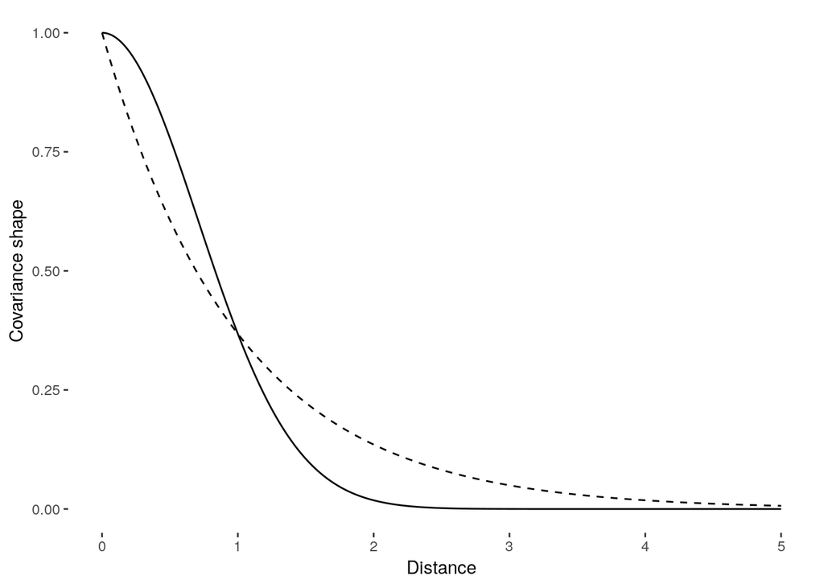

```r
ex <- data.frame(dist = seq(0, 5, by = .01)) %>%
     mutate(shape_linear = exp(-1 * dist), shape_squared = exp(-1 * dist^2))

ggplot(ex) + theme_tufte(base_family = 'sans') +
  geom_line(aes(dist, shape_linear), linetype = 'dashed') +
  geom_line(aes(dist, shape_squared)) + labs(x = 'Distance', y = 'Covariance shape')
```

Code model in Stan.

```stan
data {
  int N;            // observations
  int T[N];         // tools
  vector[N] logpop; // log population

  int N_societies;  // number of societies
  int society[N];   // index of societies
  matrix[N_societies,N_societies] Dmat; // distance matrix
}
parameters {
  real alpha;
  real beta_lpop;
  vector[N_societies] gamma;
  real<lower=0> etasq;
  real<lower=0> rhosq;
}
model {
  vector[N] lambda;
  matrix[N_societies,N_societies] K;

  // create Sigma (K) matrix
  for ( i in 1:(N_societies - 1) )
    for ( j in (i+1):N_societies ) {
      K[i,j] = etasq * exp( -rhosq * pow(Dmat[i,j],2) );
      K[j,i] = K[i,j];
      }
  for ( k in 1:N_societies )
    K[k,k] = etasq + 0.01;

  // priors
  target += multi_normal_lpdf(gamma | rep_vector(0,N_societies) , K );
  target += normal_lpdf(alpha | 0, 10);
  target += normal_lpdf(beta_lpop | 0, 1);
  target += cauchy_lpdf(etasq | 0, 1);
  target += cauchy_lpdf(rhosq | 0, 1);

  // linear model
  lambda = alpha + gamma[society] + beta_lpop * logpop;

  // likelihood
  target += poisson_log_lpmf(T | lambda);
}
```

Organize data and sample from model.

```r
dat <- list(
  N = NROW(d),
  T = d$total_tools,
  logpop = d$logpop,
  N_societies = max(d$society),
  society = d$society,
  Dmat = Dmat
)

fit13_7 <- sampling(m13_7, data = dat, iter = 1000, chains = 2, cores = 2)
```

Summary of model.

```r
print(fit13_7, probs = c(0.1, 0.5, 0.9))
```

```
## Inference for Stan model: b281d6111c8236f2dae377226b2f6235.
## 2 chains, each with iter=1000; warmup=500; thin=1;
## post-warmup draws per chain=500, total post-warmup draws=1000.
##
##             mean se_mean   sd    10%    50%    90% n_eff Rhat
## alpha       1.33    0.07 1.12  -0.09   1.36   2.79   225 1.00
## beta_lpop   0.24    0.01 0.11   0.10   0.24   0.39   272 1.00
## gamma[1]   -0.27    0.03 0.38  -0.76  -0.25   0.20   156 1.00
## gamma[2]   -0.11    0.03 0.38  -0.59  -0.09   0.36   150 1.00
## gamma[3]   -0.16    0.03 0.36  -0.62  -0.13   0.28   147 1.00
## gamma[4]    0.31    0.02 0.32  -0.06   0.31   0.71   170 1.00
## gamma[5]    0.04    0.03 0.31  -0.31   0.04   0.43   157 1.00
## gamma[6]   -0.45    0.03 0.33  -0.84  -0.42  -0.08   144 1.00
## gamma[7]    0.10    0.02 0.32  -0.26   0.11   0.48   163 1.00
## gamma[8]   -0.24    0.03 0.32  -0.61  -0.22   0.11   144 1.01
## gamma[9]    0.25    0.02 0.31  -0.12   0.26   0.61   196 1.00
## gamma[10]  -0.09    0.03 0.45  -0.58  -0.12   0.46   289 1.00
## etasq       0.31    0.02 0.36   0.06   0.20   0.69   331 1.00
## rhosq       1.48    0.28 7.69   0.08   0.44   2.17   731 1.00
## lp__      -42.62    0.16 2.80 -46.45 -42.35 -39.26   307 1.00
##
## Samples were drawn using NUTS(diag_e) at Thu Jan 17 12:21:36 2019.
## For each parameter, n_eff is a crude measure of effective sample size,
## and Rhat is the potential scale reduction factor on split chains (at
## convergence, Rhat=1).
```

Posterior distribution of the spatial covariance.

Figure 13.9

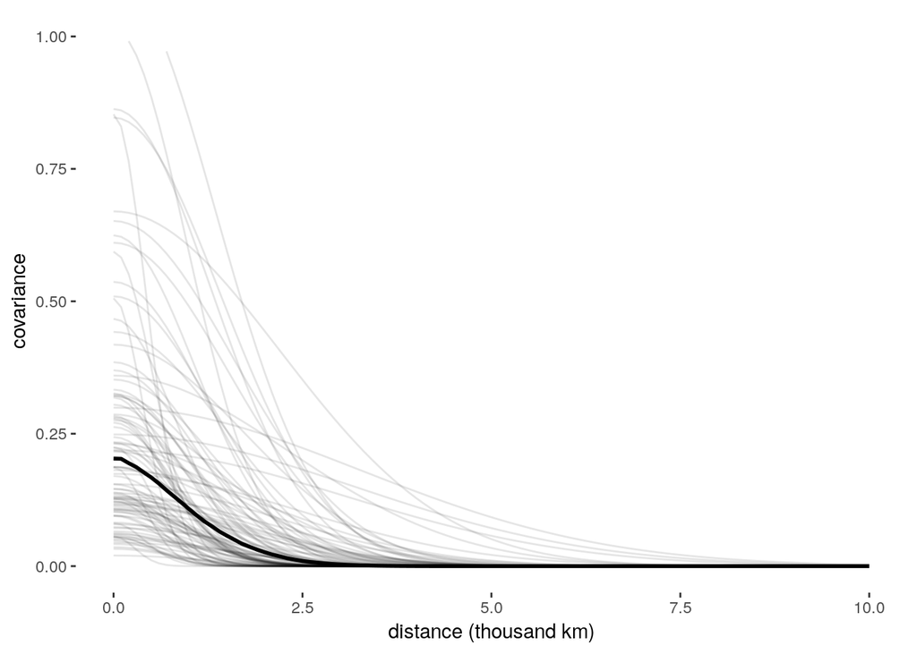

```r
post13_7 <- as.data.frame(fit13_7, pars = c('etasq', 'rhosq'))

dist     <- seq(0, 10, by = .1)

cov_dist <- diag(post13_7$etasq) %*% exp(-post13_7$rhosq %*% t(dist^2) )
colnames(cov_dist) <- dist

cov_dist <-
  as.data.frame(cov_dist) %>%
  mutate(Iter = row_number()) %>%
  tidyr::gather(key = 'dist', value = 'covariance', -Iter) %>%
  mutate(dist = as.numeric(as.character(dist)))

cov_dist_med <-
  cov_dist %>% group_by(dist) %>%
  summarise(covariance = median(covariance))

ggplot() + theme_tufte(base_family = 'sans') +
  geom_line(data = group_by(cov_dist, dist) %>% filter(row_number() <= 100),
            aes(x = dist, y = covariance, group = Iter), alpha = .1) +
  geom_line(data = cov_dist_med, aes(x = dist, y = covariance), lwd = 1) +
  scale_y_continuous(limits = c(0, 1)) +
  labs(x = 'distance (thousand km)', y = 'covariance')
```

Review correlation among the 10 societies.

```r
K <- median(post13_7$etasq) * exp(-median(post13_7$rhosq) * Dmat^2)
diag(K) <-  median(post13_7$etasq) + 0.01
Rho <- cov2cor(K)
round(Rho, 2)
```

```
##              Ml   Ti   SC   Ya   Fi   Tr   Ch   Mn   To Ha
## Malekula   1.00 0.86 0.80 0.00 0.49 0.16 0.01 0.03 0.21  0
## Tikopia    0.86 1.00 0.91 0.00 0.49 0.16 0.03 0.04 0.18  0
## Santa Cruz 0.80 0.91 1.00 0.00 0.33 0.27 0.05 0.08 0.10  0
## Yap        0.00 0.00 0.00 1.00 0.00 0.07 0.33 0.31 0.00  0
## Lau Fiji   0.49 0.49 0.33 0.00 1.00 0.01 0.00 0.00 0.74  0
## Trobriand  0.16 0.16 0.27 0.07 0.01 1.00 0.23 0.70 0.00  0
## Chuuk      0.01 0.03 0.05 0.33 0.00 0.23 1.00 0.50 0.00  0
## Manus      0.03 0.04 0.08 0.31 0.00 0.70 0.50 1.00 0.00  0
## Tonga      0.21 0.18 0.10 0.00 0.74 0.00 0.00 0.00 1.00  0
## Hawaii     0.00 0.00 0.00 0.00 0.00 0.00 0.00 0.00 0.00  1
```

Map of societies.

Figure 13.10 left side

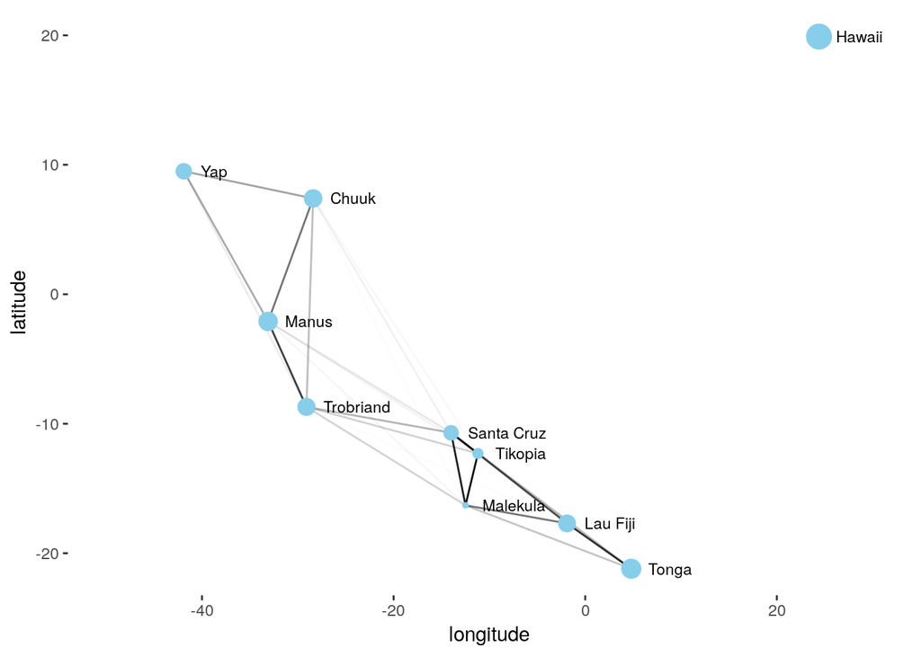

```r
colnames(Rho) <- rownames(Rho)
Rho[upper.tri(Rho, diag = T)] <- NA
Rho <- reshape2::melt(Rho, na.rm = TRUE)
colnames(Rho) <- c('culture', 'adjacent', 'correlation')
Rho <- Rho %>% left_join(d[,c('culture', 'lon2', 'lat', 'logpop', 'total_tools')], by = c('culture' = 'culture'))
Rho <- Rho %>% left_join(d[,c('culture', 'lon2', 'lat', 'logpop', 'total_tools')], by = c('adjacent' = 'culture'), suffix = c('', '.adj'))

ggplot() + theme_tufte(base_family = 'sans') +
  geom_segment(data = Rho, aes(x = lon2, xend = lon2.adj, y = lat, yend = lat.adj, alpha = correlation)) +
  geom_point(data = d, aes(lon2, lat, size = logpop), color = 'skyblue') +
  geom_text(data = d, aes(lon2+1.8, lat, label = culture), hjust = 0, size = 3) +
  scale_x_continuous(limits = c(-50, 30)) +
  scale_alpha(range = c(0, 1)) +
  theme(legend.position = '') +
  labs(x = 'longitude', y = 'latitude')
```

Plot tools versus log population.

Figure 13.10 right side

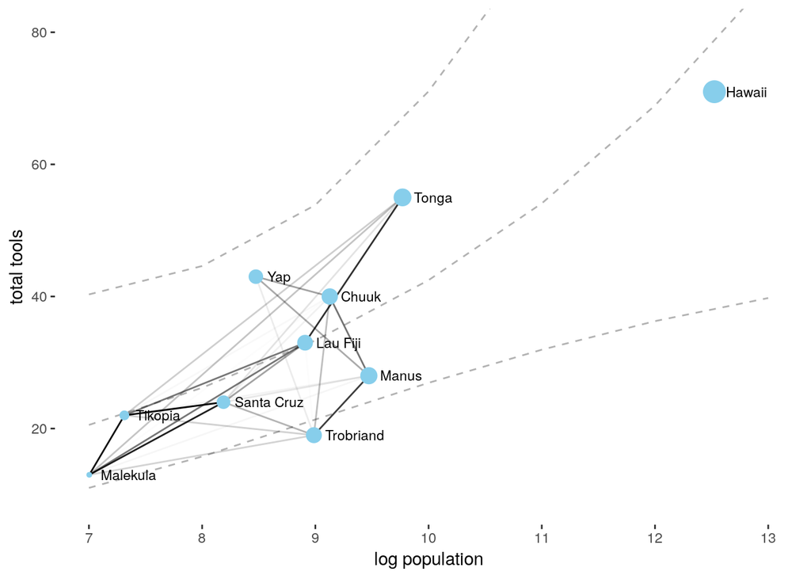

```r
post <- as.data.frame(fit13_7, pars = c('alpha', 'beta_lpop'))
tot_tools_mu <- post$alpha + post$beta_lpop %*% t(seq(6, 13))
tt_mean <- apply(tot_tools_mu, 2, mean) %>% exp()
tt_pi <- apply(tot_tools_mu, 2, rethinking::PI) %>% exp()


ggplot() + theme_tufte(base_family = 'sans') +
  geom_line(aes(x = seq(6, 13), y = tt_pi[2,]), linetype = 'dashed', alpha = .3) +
  geom_line(aes(x = seq(6, 13), y = tt_mean), linetype = 'dashed', alpha = .3) +
  geom_line(aes(x = seq(6, 13), y = tt_pi[1,]), linetype = 'dashed', alpha = .3) +
  geom_segment(data = Rho, aes(x = logpop, xend = logpop.adj,
                               y = total_tools, yend = total_tools.adj,
                               alpha = correlation)) +
  geom_point(data = d, aes(logpop, total_tools, size = logpop), color = 'skyblue') +
  geom_text(data = d, aes(logpop + .1, total_tools, label = culture), hjust = 0, size = 3) +
  scale_x_continuous(limits = c(7, 13), breaks = seq(7, 13)) +
  coord_cartesian(ylim = c(9, 80)) +
  scale_alpha(range = c(0, 1)) +
  theme(legend.position = '') +
  labs(x = 'log population', y = 'total tools')
```